# HTP Exercise Codility

# Step #1 - Import data into R DataFrame

The goal here is to import the data available into a R Dataframe. Currently, the data contains a counter which is a unique identifier of the experiment/sample/try, the plate number (a identifier factor), the strain which (a identifier factor), the well_type (a identifier factor),the robot (a identifier factor), the stacker position (a identifier factor) and the value obtained.

```r
library(readxl)
data <- read_excel("data.xlsx")

#Fix type of data
data$plate <- as.factor(data$plate)
data$strain <- as.factor(data$strain)
data$well_type <- as.factor(data$well_type)
data$robot <- as.factor(data$robot)
```

# Step #2 - Summarise the data.

By running a summary on the complete dataframe we can get some useful information.

```r
summary(data)
```

```
    counter         plate          strain               well_type
 Min.   :   1   1      :  96   Y0001  : 240   Parent Strain  : 240
 1st Qu.:1441   2      :  96   Y0002  : 240   Process Control: 240
 Median :2880   3      :  96   X1     :   1   Standard Well  :5280
 Mean   :2880   4      :  96   X10    :   1
 3rd Qu.:4320   5      :  96   X100   :   1
 Max.   :5760   6      :  96   X1000  :   1
                (Other):5184   (Other):5276
        robot      stacker_position     value
 Bender    :1920   Min.   : 1.00    Min.   : 5970
 C3P0      :1920   1st Qu.: 5.75    1st Qu.: 8384
 Terminator:1920   Median :10.50    Median : 8908
                   Mean   :10.50    Mean   : 8885
                   3rd Qu.:15.25    3rd Qu.: 9443
                   Max.   :20.00    Max.   :11194
```

# Step #3 - Hypothesis testing

The factors plate, well_type and robot will be put to null hypothesis testing individually and in combination in ANOVA and 2-way ANOVA.

## Step #3.1 - Plate ANOVA

```r
library(dplyr)
group_by(data, plate) %>%
  summarise(
    count = n(),
    mean = mean(value, na.rm = TRUE),
    sd = sd(value, na.rm = TRUE)
  )
```

| plate | count | mean | sd |
| --- | --- | --- | --- |
| 1 | 96 | 9874.368 | 520.8416 |
| 2 | 96 | 9697.845 | 491.0632 |
| 3 | 96 | 9614.044 | 428.9457 |
| 4 | 96 | 9522.700 | 457.3086 |
| 5 | 96 | 9392.100 | 567.2343 |
| 6 | 96 | 9285.998 | 452.7008 |
| 7 | 96 | 9237.237 | 443.6683 |
| 8 | 96 | 9137.093 | 391.8420 |
| 9 | 96 | 9059.005 | 443.3506 |
| 10 | 96 | 8949.918 | 403.2322 |

[output cut: 50 more lines]

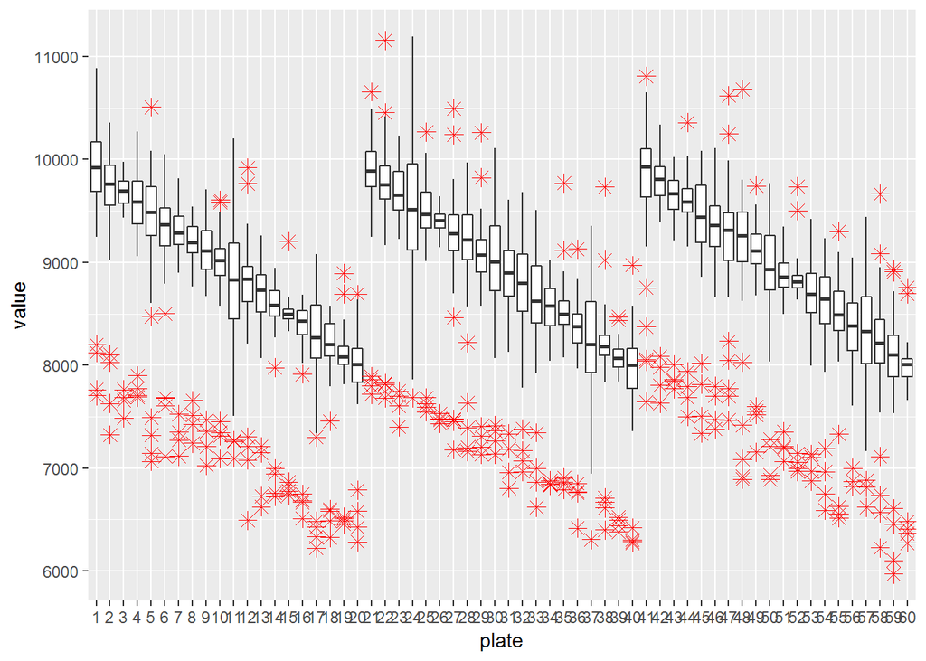

```r
library(ggplot2)
ggplot(data, aes(x=plate, y=value)) + geom_boxplot(outlier.colour="red", outlier.shape=8,outlier.size=3)
```

```r
res.aov <- aov(value ~ plate, data)
summary(res.aov)
```

```
              Df    Sum Sq  Mean Sq F value Pr(>F)
plate         59 1.855e+09 31433219   148.3 <2e-16 ***
Residuals   5700 1.208e+09   211890
---
Signif. codes:  0 '***' 0.001 '**' 0.01 '*' 0.05 '.' 0.1 ' ' 1
```

By doing an ANOVA on plate factor, testing our null hypothesis means of the independent variable (value) does not vary between the different plates. As we can see in the figure above and supported by the ANOVA analysis there are significant differences between the means of the value grouped by plate. More specifically, by the analysis of the figure it seems that the plates 1-20,21-40, and 41-60 were iteratively analysed and the mean of the value is decreasing in each iteration. A more profund analysis of the dataset reveals that the plates 1-20, 21-40 and 41-60 were analyzed by Bender, Terminator and C3PO respectively. Another relevant information is that the tested strains do not repeat themselfs across both plates or robots.Several obvious outliers were observed, maybe revealing strains of interest or contaminations.

## Step #3.2 - Well Type ANOVA

```r
library(dplyr)
group_by(data, well_type) %>%
  summarise(
    count = n(),
    mean = mean(value, na.rm = TRUE),
    sd = sd(value, na.rm = TRUE)
  )
```

| well_type | count | mean | sd |
| --- | --- | --- | --- |
| Parent Strain | 240 | 8938.219 | 643.9763 |
| Process Control | 240 | 7168.719 | 505.1185 |
| Standard Well | 5280 | 8960.238 | 640.3612 |

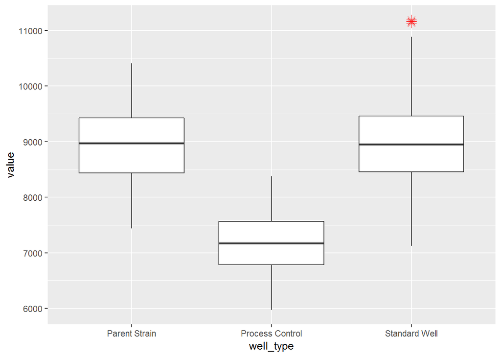

```r
library(ggplot2)
ggplot(data, aes(x=well_type, y=value)) + geom_boxplot(outlier.colour="red", outlier.shape=8,outlier.size=3)
```

```r
res.aov <- aov(value ~ well_type, data)
summary(res.aov)
```

```
              Df    Sum Sq   Mean Sq F value Pr(>F)
well_type      2 7.375e+08 368758280   913.2 <2e-16 ***
Residuals   5757 2.325e+09    403824
---
Signif. codes:  0 '***' 0.001 '**' 0.01 '*' 0.05 '.' 0.1 ' ' 1
```

By doing an ANOVA on well_type factor, testing our null hypothesis means of the independent variable (value) does not vary between the different weel_types. As we can see in the figure above and supported by the ANOVA analysis there are significant differences between the means of the value grouped by well_type, since Process Control class seems to have overall lower mean. Standard well outlier may be our strains of interest.

## Step #3.3 - Robot ANOVA

```r
library(dplyr)
group_by(data, robot) %>%
  summarise(
    count = n(),
    mean = mean(value, na.rm = TRUE),
    sd = sd(value, na.rm = TRUE)
  )
```

| robot | count | mean | sd |
| --- | --- | --- | --- |
| Bender | 1920 | 8882.527 | 722.9964 |
| C3P0 | 1920 | 8891.309 | 718.6991 |
| Terminator | 1920 | 8880.186 | 745.9718 |

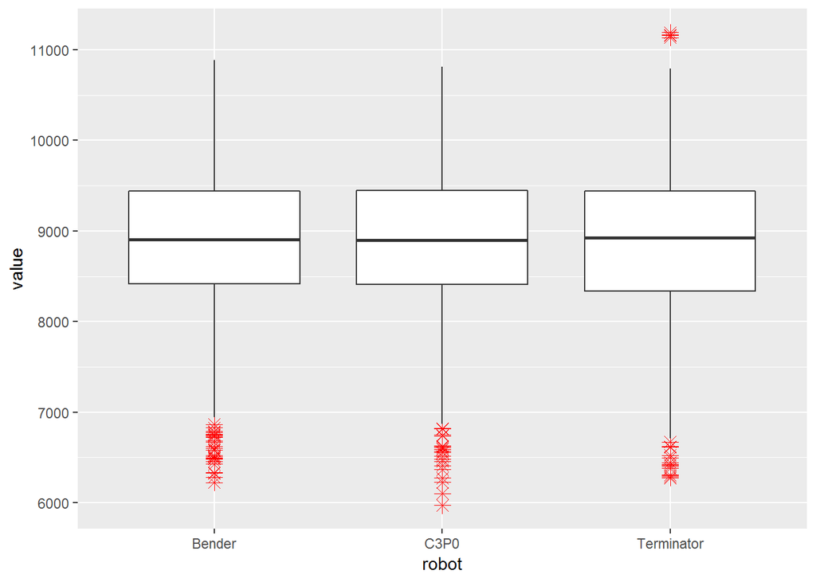

```r
library(ggplot2)
ggplot(data, aes(x=robot, y=value)) + geom_boxplot(outlier.colour="red", outlier.shape=8,outlier.size=3)
```

```r
res.aov <- aov(value ~ robot, data)
summary(res.aov)
```

```
              Df    Sum Sq Mean Sq F value Pr(>F)
robot          2 1.320e+05   66021   0.124  0.883
Residuals   5757 3.062e+09  531909
```

By doing an ANOVA on robot factor, testing our null hypothesis means of the independent variable (value) does not vary between the different robots. As we can see in the figure above and supported by the ANOVA analysis there are no significant differences between the means of the value grouped by robot. This confirms what was seen in the plate ANOVA, that although the mean over plate number decreases in each robot plate set (1-20,21-40,etc) there are no statistically significant differentes between the three sets.Moreover, low value outlier are recorrent in all boxplots as seen in the image shich correspond to the PC samples.

## Step #3.4 - Two-way ANOVA (Well Type vs Robot)

```r
require("dplyr")
group_by(data, well_type, robot) %>%
  summarise(
    count = n(),
    mean = mean(value, na.rm = TRUE),
    sd = sd(value, na.rm = TRUE)
  )
```

| well_type | robot | count | mean | sd |
| --- | --- | --- | --- | --- |
| Parent Strain | Bender | 80 | 8966.676 | 660.5975 |
| Parent Strain | C3P0 | 80 | 8908.743 | 601.9182 |
| Parent Strain | Terminator | 80 | 8939.237 | 673.9582 |
| Process Control | Bender | 80 | 7137.272 | 503.4266 |
| Process Control | C3P0 | 80 | 7206.801 | 540.2835 |
| Process Control | Terminator | 80 | 7162.085 | 473.3227 |
| Standard Well | Bender | 1760 | 8958.031 | 628.2787 |
| Standard Well | C3P0 | 1760 | 8967.085 | 631.9157 |
| Standard Well | Terminator | 1760 | 8955.598 | 660.7032 |

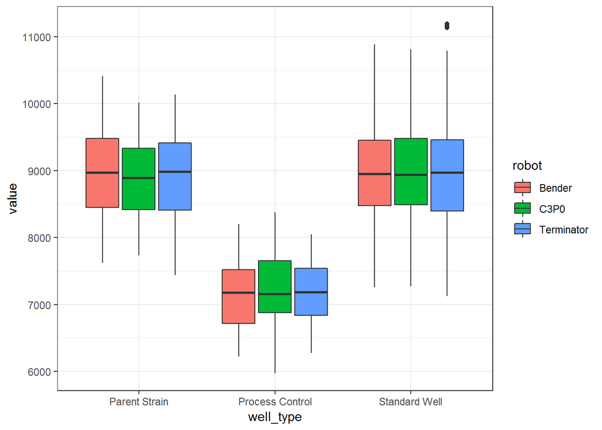

```r
library(ggplot2)
ggplot(data = data, aes(x = well_type, y = value)) +
geom_boxplot(aes(fill = robot), width = 0.8) + theme_bw()
```

```r
res.aov2 <- aov(value ~ well_type * robot, data = data)
summary(res.aov2)
```

```
                  Df    Sum Sq   Mean Sq F value Pr(>F)
well_type          2 7.375e+08 368758280 912.396 <2e-16 ***
robot              2 1.320e+05     66021   0.163  0.849
well_type:robot    4 3.300e+05     82489   0.204  0.936
Residuals       5751 2.324e+09    404165
---
Signif. codes:  0 '***' 0.001 '**' 0.01 '*' 0.05 '.' 0.1 ' ' 1
```

Accordingly, to the 2-way ANOVA test between the well_type and robot variables, no significant difference could be found in the means of the samples in relation to the factor interaction. As verified before there is a statistical difference between the means of samples in relation to the well_type itself.

## Step 3.5 - Two-way ANOVA (Plate vs Robot)

```r
require("dplyr")
group_by(data, plate, robot) %>%
  summarise(
    count = n(),
    mean = mean(value, na.rm = TRUE),
    sd = sd(value, na.rm = TRUE)
  )
```

| plate | robot | count | mean | sd |
| --- | --- | --- | --- | --- |
| 1 | Bender | 96 | 9874.368 | 520.8416 |
| 2 | Bender | 96 | 9697.845 | 491.0632 |
| 3 | Bender | 96 | 9614.044 | 428.9457 |
| 4 | Bender | 96 | 9522.700 | 457.3086 |
| 5 | Bender | 96 | 9392.100 | 567.2343 |
| 6 | Bender | 96 | 9285.998 | 452.7008 |
| 7 | Bender | 96 | 9237.237 | 443.6683 |
| 8 | Bender | 96 | 9137.093 | 391.8420 |
| 9 | Bender | 96 | 9059.005 | 443.3506 |
| 10 | Bender | 96 | 8949.918 | 403.2322 |

[output cut: 50 more lines]

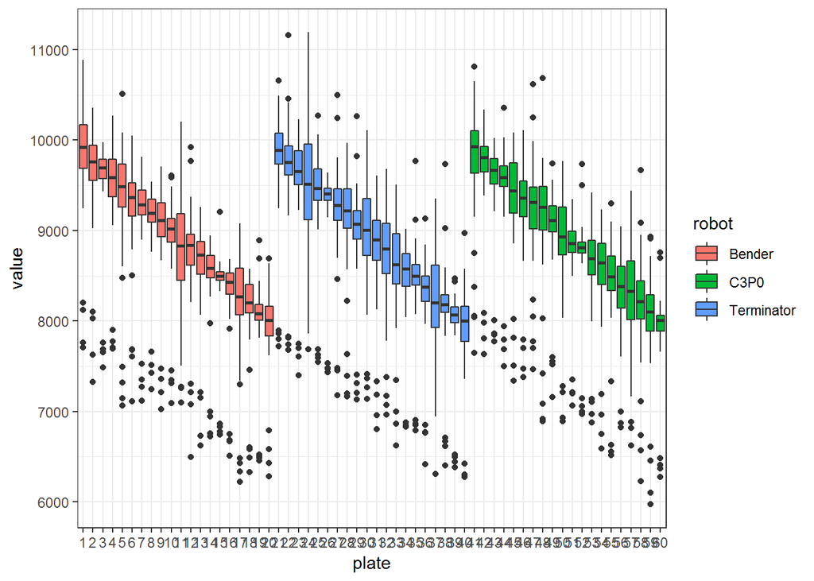

```r
library(ggplot2)
ggplot(data = data, aes(x = plate, y = value)) +
geom_boxplot(aes(fill = robot), width = 0.8) + theme_bw()
```

```r
res.aov2 <- aov(value ~ plate*robot, data = data)
summary(res.aov2)
```

```
              Df    Sum Sq  Mean Sq F value Pr(>F)
plate         59 1.855e+09 31433219   148.3 <2e-16 ***
Residuals   5700 1.208e+09   211890
---
Signif. codes:  0 '***' 0.001 '**' 0.01 '*' 0.05 '.' 0.1 ' ' 1
```

The 2-way ANOVA test between the plate and robot variables, produces no relevant information since as verified before the samples are only attributed to a single robot. As verified before there is a statistical difference between the means of samples in relation to the plate itself.

## Step 3.6 - Two-way ANOVA (Plate vs Well Type)

```r
require("dplyr")
group_by(data, plate, well_type) %>%
  summarise(
    count = n(),
    mean = mean(value, na.rm = TRUE),
    sd = sd(value, na.rm = TRUE)
  )
```

| plate | well_type | count | mean | sd |
| --- | --- | --- | --- | --- |
| 1 | Parent Strain | 4 | 10163.960 | 231.66276 |
| 1 | Process Control | 4 | 7947.285 | 251.07600 |
| 1 | Standard Well | 88 | 9948.800 | 334.65575 |
| 2 | Parent Strain | 4 | 9800.224 | 286.21431 |
| 2 | Process Control | 4 | 7771.725 | 363.91965 |
| 2 | Standard Well | 88 | 9780.742 | 279.14308 |
| 3 | Parent Strain | 4 | 9619.287 | 80.27604 |
| 3 | Process Control | 4 | 7647.673 | 117.16992 |
| 3 | Standard Well | 88 | 9703.186 | 120.01489 |
| 4 | Parent Strain | 4 | 9771.888 | 95.47851 |

[output cut: 170 more lines]

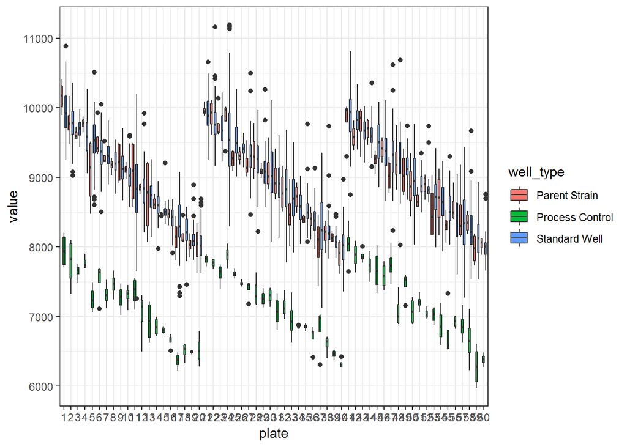

```r
library(ggplot2)
ggplot(data = data, aes(x = plate, y = value)) +
geom_boxplot(aes(fill = well_type), width = 0.8) + theme_bw()
```

```r
res.aov2 <- aov(value ~ plate * well_type, data = data)
summary(res.aov2)
```

```
                  Df    Sum Sq   Mean Sq  F value Pr(>F)
plate             59 1.855e+09  31433219  382.477 <2e-16 ***
well_type          2 7.375e+08 368758280 4487.028 <2e-16 ***
plate:well_type  118 1.167e+07     98912    1.204 0.0678 .
Residuals       5580 4.586e+08     82183
---
Signif. codes:  0 '***' 0.001 '**' 0.01 '*' 0.05 '.' 0.1 ' ' 1
```

# Step #4 - Problem Statement Evaluation

Accordingly to the observed data, several assumptions to the problem statement seem evident:

- The counter variable is a sample unique identifier.
- The stacker_position variable is a positional identifier of each plate in the robot, and does not seem contributive to the problem although not verified statistically.
- The same PC and PS strains were used for all plates, repeating the analysis 4 times for each.
- 88 unique strains (X’s) were analysed as SW for plate and do not repeate for each plate or in mutiple plates.
- The same plates are not analyzed by multiple robots.
- The robots analysis return the same variable - value.
- Whithin a single robot analysis (ex: Bender), there is a set of plates (ex: 1-20) which have a decreasing trend of the value variable mean in the plates assuming the plate order. If it is a iterative process, and the plate number represents each iteration, the value is progressively decreasing for each iteration. However, plate number could be designated based on other criteria or not be ordered at all.

Further assumptions, hereby described, were taken in consideration:

- Both the plate and robot variability should be taken in consideration when selecting strains
- Assuming independece between samples.
- The goal is to select strains with higher value.

# Step #5 - Data Treatment

In order to normalize the data in each plate, we can first normalize each sample accordingly to the PC sample mean and sample variance:

```r
data1<-group_by(data,plate, well_type)%>%summarise(mean = mean(value, na.rm = TRUE),
    sd = sd(value, na.rm = TRUE))%>%filter(well_type=="Process Control")%>%merge(data,by="plate")%>%mutate(value_pc = (value-mean)/sd)
data1
```

| plate | well_type.x | mean | sd | counter | strain | well_type.y | robot | stacker_position | value | value_pc |
| --- | --- | --- | --- | --- | --- | --- | --- | --- | --- | --- |
| 1 | Process Control | 7947.285 | 251.07600 | 1 | X1 | Standard Well | Bender | 1 | 10235.738 | 9.11458064 |
| 1 | Process Control | 7947.285 | 251.07600 | 2 | X2 | Standard Well | Bender | 1 | 10369.994 | 9.64930247 |
| 1 | Process Control | 7947.285 | 251.07600 | 3 | X3 | Standard Well | Bender | 1 | 9651.469 | 6.78752176 |
| 1 | Process Control | 7947.285 | 251.07600 | 4 | X4 | Standard Well | Bender | 1 | 10171.884 | 8.86026206 |
| 1 | Process Control | 7947.285 | 251.07600 | 5 | X5 | Standard Well | Bender | 1 | 9493.364 | 6.15781244 |
| 1 | Process Control | 7947.285 | 251.07600 | 6 | X6 | Standard Well | Bender | 1 | 10216.470 | 9.03784195 |
| 1 | Process Control | 7947.285 | 251.07600 | 7 | X7 | Standard Well | Bender | 1 | 9884.500 | 7.71565187 |
| 1 | Process Control | 7947.285 | 251.07600 | 8 | X8 | Standard Well | Bender | 1 | 10450.230 | 9.96887477 |
| 1 | Process Control | 7947.285 | 251.07600 | 9 | X9 | Standard Well | Bender | 1 | 10153.507 | 8.78706564 |
| 1 | Process Control | 7947.285 | 251.07600 | 10 | X10 | Standard Well | Bender | 1 | 10616.108 | 10.62954093 |

[output cut: 5750 more lines]

Similarly, the mean of the PS was calculated for each plate,

```r
data2<-group_by(data1,plate,well_type.y)%>%summarise(mean1 = mean(value_pc, na.rm = TRUE),
    sd1 = sd(value_pc, na.rm = TRUE))%>%filter(well_type.y=="Parent Strain")%>%merge(data1,by="plate")
data2
```

| plate | well_type.y.x | mean1 | sd1 | well_type.x | mean | sd | counter | strain | well_type.y.y | robot | stacker_position | value | value_pc |
| --- | --- | --- | --- | --- | --- | --- | --- | --- | --- | --- | --- | --- | --- |
| 1 | Parent Strain | 8.828701 | 0.9226798 | Process Control | 7947.285 | 251.07600 | 1 | X1 | Standard Well | Bender | 1 | 10235.738 | 9.11458064 |
| 1 | Parent Strain | 8.828701 | 0.9226798 | Process Control | 7947.285 | 251.07600 | 2 | X2 | Standard Well | Bender | 1 | 10369.994 | 9.64930247 |
| 1 | Parent Strain | 8.828701 | 0.9226798 | Process Control | 7947.285 | 251.07600 | 3 | X3 | Standard Well | Bender | 1 | 9651.469 | 6.78752176 |
| 1 | Parent Strain | 8.828701 | 0.9226798 | Process Control | 7947.285 | 251.07600 | 4 | X4 | Standard Well | Bender | 1 | 10171.884 | 8.86026206 |
| 1 | Parent Strain | 8.828701 | 0.9226798 | Process Control | 7947.285 | 251.07600 | 5 | X5 | Standard Well | Bender | 1 | 9493.364 | 6.15781244 |
| 1 | Parent Strain | 8.828701 | 0.9226798 | Process Control | 7947.285 | 251.07600 | 6 | X6 | Standard Well | Bender | 1 | 10216.470 | 9.03784195 |
| 1 | Parent Strain | 8.828701 | 0.9226798 | Process Control | 7947.285 | 251.07600 | 7 | X7 | Standard Well | Bender | 1 | 9884.500 | 7.71565187 |
| 1 | Parent Strain | 8.828701 | 0.9226798 | Process Control | 7947.285 | 251.07600 | 8 | X8 | Standard Well | Bender | 1 | 10450.230 | 9.96887477 |
| 1 | Parent Strain | 8.828701 | 0.9226798 | Process Control | 7947.285 | 251.07600 | 9 | X9 | Standard Well | Bender | 1 | 10153.507 | 8.78706564 |
| 1 | Parent Strain | 8.828701 | 0.9226798 | Process Control | 7947.285 | 251.07600 | 10 | X10 | Standard Well | Bender | 1 | 10616.108 | 10.62954093 |

[output cut: 5750 more lines]

# Step #6 - Selection of Strains

```r
final<-mutate(data2,optimal = value_pc > mean1*(sd1*3))%>%filter(optimal == TRUE)%>%filter(well_type.y.y == 'Standard Well')%>%arrange(value_pc)
final
```

| plate | well_type.y.x | mean1 | sd1 | well_type.x | mean | sd | counter | strain | well_type.y.y | robot | stacker_position | value | value_pc | optimal |
| --- | --- | --- | --- | --- | --- | --- | --- | --- | --- | --- | --- | --- | --- | --- |
| 12 | Parent Strain | 5.016403 | 0.1815825 | Process Control | 7021.481 | 363.9259 | 1111 | X1023 | Standard Well | Bender | 12 | 8208.202 | 3.260885 | TRUE |
| 12 | Parent Strain | 5.016403 | 0.1815825 | Process Control | 7021.481 | 363.9259 | 1133 | X1045 | Standard Well | Bender | 12 | 8314.747 | 3.553652 | TRUE |
| 12 | Parent Strain | 5.016403 | 0.1815825 | Process Control | 7021.481 | 363.9259 | 1072 | X984 | Standard Well | Bender | 12 | 8337.980 | 3.617492 | TRUE |
| 12 | Parent Strain | 5.016403 | 0.1815825 | Process Control | 7021.481 | 363.9259 | 1119 | X1031 | Standard Well | Bender | 12 | 8357.212 | 3.670338 | TRUE |
| 12 | Parent Strain | 5.016403 | 0.1815825 | Process Control | 7021.481 | 363.9259 | 1079 | X991 | Standard Well | Bender | 12 | 8359.229 | 3.675880 | TRUE |
| 12 | Parent Strain | 5.016403 | 0.1815825 | Process Control | 7021.481 | 363.9259 | 1098 | X1010 | Standard Well | Bender | 12 | 8360.039 | 3.678106 | TRUE |
| 12 | Parent Strain | 5.016403 | 0.1815825 | Process Control | 7021.481 | 363.9259 | 1073 | X985 | Standard Well | Bender | 12 | 8387.558 | 3.753724 | TRUE |
| 12 | Parent Strain | 5.016403 | 0.1815825 | Process Control | 7021.481 | 363.9259 | 1134 | X1046 | Standard Well | Bender | 12 | 8480.870 | 4.010128 | TRUE |
| 12 | Parent Strain | 5.016403 | 0.1815825 | Process Control | 7021.481 | 363.9259 | 1109 | X1021 | Standard Well | Bender | 12 | 8487.712 | 4.028927 | TRUE |
| 12 | Parent Strain | 5.016403 | 0.1815825 | Process Control | 7021.481 | 363.9259 | 1132 | X1044 | Standard Well | Bender | 12 | 8488.012 | 4.029753 | TRUE |

[output cut: 102 more lines]

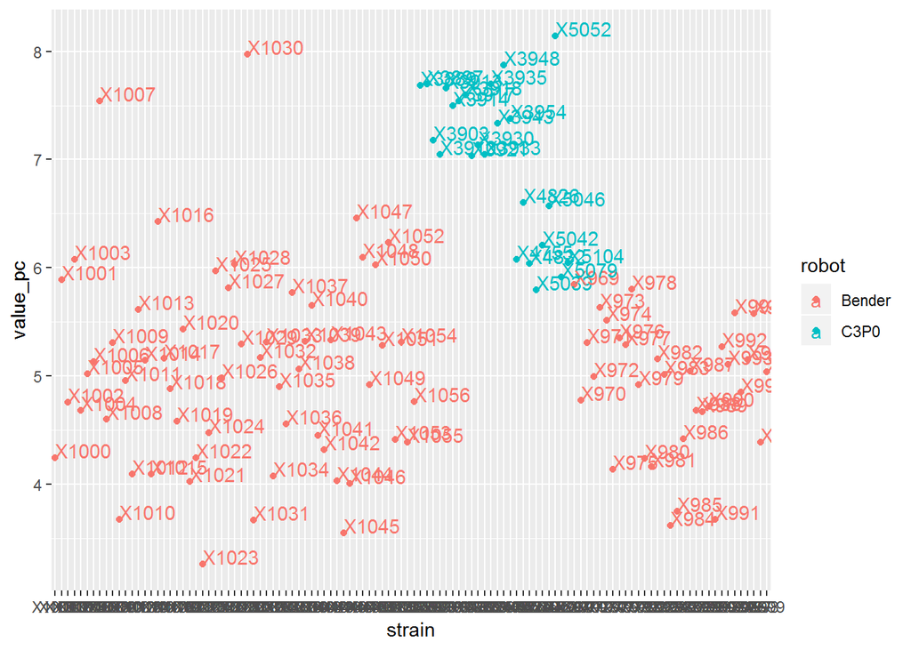

```r
library(ggplot2)
ggplot(final, aes(x= strain, y= value_pc, color=robot))+
  geom_point() +geom_text(aes(label=strain),hjust=0, vjust=0)
```